# Обработка таблицы каунтов с помощью DESeq

In this project it was necessary to reanalyze the article doi:10.3390/genes11091057 on the analysis of RNA sequencing data.

Samples: wt_contr 232_contr wt_HS 232_HS, where HS - myogenic differentiation.

## Processing of the table of counts in DESeq2.

Libraries:

```r
require("DESeq2")
require("dplyr")
require('pheatmap')
require(devtools)
#BiocManager::install("fgsea")
require(data.table)
#BiocManager::install("fgsea")
require(fgsea)
require(ggplot2)
#install.packages('pheatmap')
require('pheatmap')
#install.packages('msigdbr')
require(msigdbr)
require(AnnotationDbi)
#install.packages('processx')
require(devtools)
require('clusterProfiler')
require(enrichplot)
require(DOSE)
#BiocManager::install("org.Mm.eg.db")
```

Loading the table of counts from a file on the computer.

```r
table_count <- read.table("Counts.Rmatrix2.txt", header=TRUE, row.names =1)
```

Let’s remove the X before 232 in the title

```r
tags <- sapply(colnames(table_count), function (x) sub("X", "", basename(x)))
colnames(table_count) <- tags
```

Condition of the experiment:

```r
cond <- data.frame(read.csv("Conditions_IB.tsv", header=T, sep = '\t', row.names = 1))
```

Creation DESEq2 dataset

```r
samples = names(table_count)
dds = DESeqDataSetFromMatrix(countData=table_count, colData=cond, design = ~ Condition)
#dds <- dds[rowSums(counts(dds)) > 20, ] # Можно сделать фильтр. Оставили гены, где больше 20 каунтов в сумме. На данном этапе не нужно.
dds <- DESeq(dds) #Нормализация
res <- results(dds)
res
```

```
## log2 fold change (MLE): Condition wt HS vs 232 contr
## Wald test p-value: Condition wt HS vs 232 contr
## DataFrame with 55487 rows and 6 columns
##                              baseMean    log2FoldChange
##                             <numeric>         <numeric>
## ENSMUSG00000102693 0.0753714884782651 0.591383831829141
## ENSMUSG00000064842                  0                NA
## ENSMUSG00000051951                  0                NA
## ENSMUSG00000102851                  0                NA
## ENSMUSG00000103377                  0                NA
## ...                               ...               ...
## ENSMUSG00000094431                  0                NA
## ENSMUSG00000094621                  0                NA
## ENSMUSG00000098647                  0                NA
## ENSMUSG00000096730                  0                NA
## ENSMUSG00000095742   646.058887592769  0.39920675105879
##                               lfcSE              stat
##                           <numeric>         <numeric>
## ENSMUSG00000102693 4.40735632396697 0.134181080075878
## ENSMUSG00000064842               NA                NA
## ENSMUSG00000051951               NA                NA
## ENSMUSG00000102851               NA                NA
## ENSMUSG00000103377               NA                NA
## ...                             ...               ...
## ENSMUSG00000094431               NA                NA
## ENSMUSG00000094621               NA                NA
## ENSMUSG00000098647               NA                NA
## ENSMUSG00000096730               NA                NA
## ENSMUSG00000095742 0.15024585778824  2.65702334117883
##                                 pvalue               padj
##                              <numeric>          <numeric>
## ENSMUSG00000102693   0.893259386521147                 NA
## ENSMUSG00000064842                  NA                 NA
## ENSMUSG00000051951                  NA                 NA
## ENSMUSG00000102851                  NA                 NA
## ENSMUSG00000103377                  NA                 NA
## ...                                ...                ...
## ENSMUSG00000094431                  NA                 NA
## ENSMUSG00000094621                  NA                 NA
## ENSMUSG00000098647                  NA                 NA
## ENSMUSG00000096730                  NA                 NA
## ENSMUSG00000095742 0.00788339846186703 0.0208340259767069
```

PCA plot for samples. Save picture.

```r
png("PCA_plot.png", 1000, 1000, pointsize=20)
vst_dds <- vst(dds)
counts.norm <- assay(vst_dds)
PCA_plot <- plotPCA(vst_dds,intgroup=c("Condition"))
PCA_plot
dev.off()
```

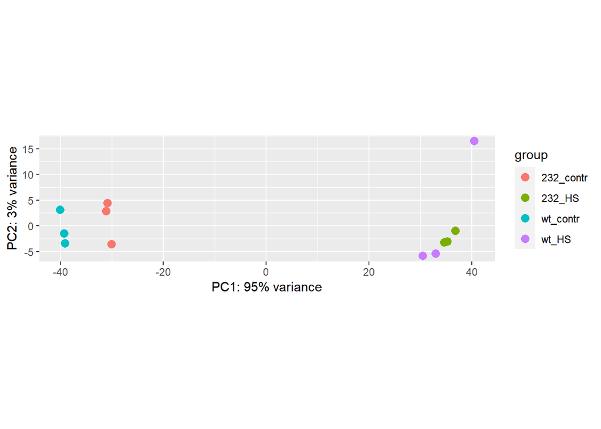

```r
PCA_plot
```

Volcanoplot. No filtration of the genes. Save in file. Red - unreliable gene expression changes.

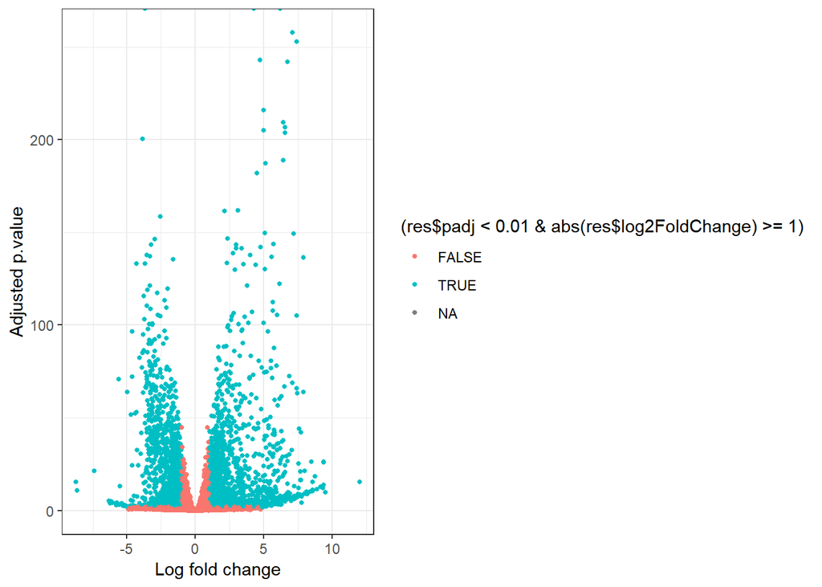

```r
gdata <- data.frame(
  x=res$log2FoldChange,
  y=-log10(res$padj)
)
#png("Volcanoplot_before.png", 500, 500, pointsize=30)
ggplot(data=gdata, aes(x=x, y=y, color = (res$padj<0.01 & abs(res$log2FoldChange) >= 1) )) +
  geom_point(size=1) + theme_bw()  +
  xlab("Log fold change") +
  ylab("Adjusted p.value")
```

```r
#dev.off()
```

Sorting.

```r
sorted <- res[with(res, order(padj, -log2FoldChange)), ] # 16289 genes
```

Remove NA values. Gene filtering padj<0.01 and abs(log2FoldChange)>1. It’s need to ClusterProfiler analysis (Further)

```r
sorted_df <- data.frame("id"=rownames(sorted),sorted)
sorted_df <- na.omit(sorted_df) #удалили NA
p_adj_below_0.01 <- sorted_df %>% filter(padj<0.01 & abs(log2FoldChange)>1) #filtering with padj и log2FoldChange
```

Heatmap graph.

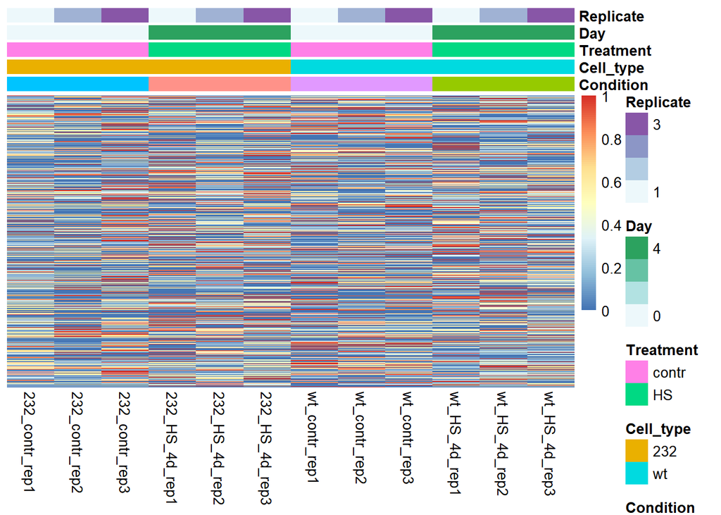

```r
counts.norm <- counts(dds, normalized=TRUE)
#png("heatmap_large.png", width=6, height=20, units="in", res=300)
to_visualise <- counts.norm[rownames(res), order(cond[, 2])]
to_visualise <- t(apply(to_visualise, 1, function(r) {
  (r - min(r)) / (max(r) - min(r))
}))
to_visualise <- na.omit(to_visualise)
#install.packages('pheatmap')
require('pheatmap')

pheatmap(to_visualise,
         show_rownames = F, cluster_rows = F,
         cluster_cols=F,
         annotation_col = cond)
```

```r
#dev.off()
```

Dispersion spread:

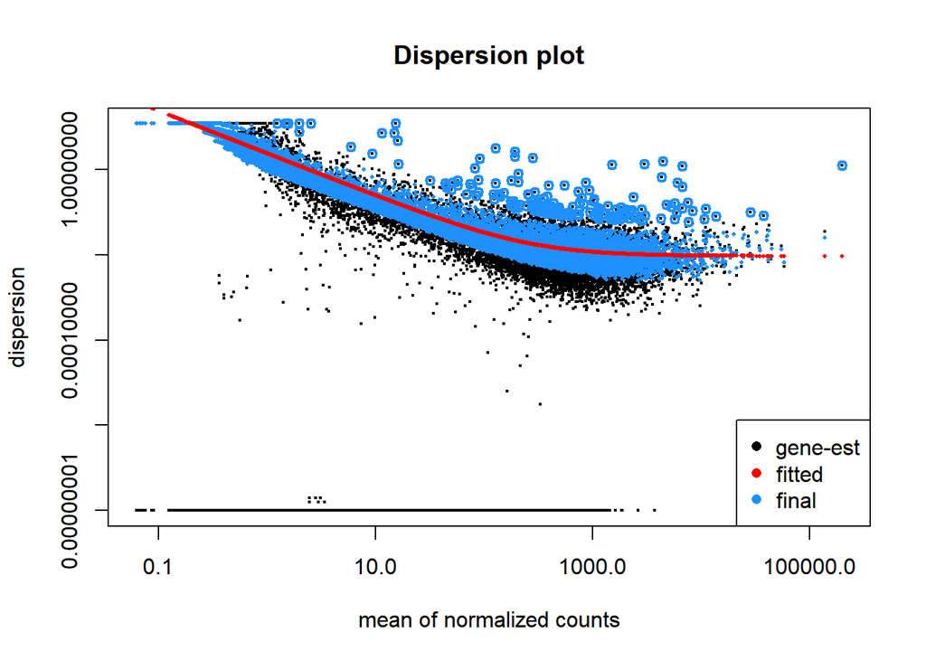

```r
#png("qc-dispersions.png", 1000, 1000, pointsize=20)
plotDispEsts(dds, main="Dispersion plot")
```

```r
#dev.off()
```

## Fast Gene Set Enrichment Analysis (GSEA) Using fgsea package

```r
#install.packages('msigdbr')
require(msigdbr)
require(AnnotationDbi)
#install.packages('processx')
require(devtools)
#BiocManager::install("fgsea") #ввести в командную строку
require(data.table)
require(fgsea)
require(ggplot2)
```

```r
BiocManager::install("org.Mm.eg.db")
organism = "org.Mm.eg.db"
BiocManager::install(organism, character.only = TRUE)
require(organism, character.only = TRUE)
```

```r
load("C:/R/IB/Projects/Data/mouse_c5_v5p2.rdata")
pathways <- Mm.c5 # скачала с сайта http://bioinf.wehi.edu.au/software/MSigDB/ категория С5
```

### wt_contr vs 232_contr

Let us carry out a comparative analysis of differentially expressed genes between the wt_contr and 232_contr groups. Let’s see which genes were influenced by the 232 mutation in LMNA.

```r
# wt_contr vs 232_contr
require('clusterProfiler')
require(enrichplot)
require(DOSE)
```

```r
de <- results(dds, contrast = c("Condition", "wt_contr", "232_contr"))
de_Genes <- row.names(de)
de$row_Genes <- de_Genes
de <- as.data.table(de)
de <- na.omit(de)
de$row_Genes <- as.character(de$row_Genes)
de[, row_Genes2 := mapIds(org.Mm.eg.db, keys=row_Genes,
                                        keytype="ENSEMBL", column="SYMBOL")] #new column with SYMBOL gene
de <- unique(de, by = "row_Genes")
#de <- unique(de, by = "row_Genes2")
de <-de[order(de$padj),] #sorting
write.csv(de, "table_de.csv")
gene_list_de <- de$log2FoldChange
genes <- bitr(de$row_Genes,
              fromType = "ENSEMBL",
              toType = "ENTREZID",
              OrgDb = org.Mm.eg.db)
names(gene_list_de) <- genes$ENTREZID
#for fgsea need to create named vector with ENTREZID and log2FoldChange values.
fr_de <- fgsea(pathways, gene_list_de, nperm = 100000, nproc=4, minSize=15, maxSize=500)
#head(fr_de[order(pval), ])
fr_de[order(padj)]
```

```
##                                                     pathway      pval
##    1:                          GO_MUSCLE_TISSUE_DEVELOPMENT 0.0000105
##    2:                           GO_MUSCLE_ORGAN_DEVELOPMENT 0.0000105
##    3:                      GO_ACTIN_MYOSIN_FILAMENT_SLIDING 0.0000136
##    4:               GO_STRIATED_MUSCLE_CELL_DIFFERENTIATION 0.0000110
##    5:                    GO_REGULATION_OF_HEART_CONTRACTION 0.0000111
##   ---
## 4519:                 GO_REGULATION_OF_VACUOLE_ORGANIZATION 0.9978600
## 4520:      GO_PROTEIN_MODIFICATION_BY_SMALL_PROTEIN_REMOVAL 0.9979261
## 4521: GO_MITOCHONDRIAL_RESPIRATORY_CHAIN_COMPLEX_I_ASSEMBLY 0.9975550
## 4522:                GO_NADH_DEHYDROGENASE_COMPLEX_ASSEMBLY 0.9975550
## 4523:                  GO_RNA_SECONDARY_STRUCTURE_UNWINDING 0.9996762
##          padj     ES    NES nMoreExtreme size
##    1: 0.00175 -0.474 -1.769            0  303
##    2: 0.00175 -0.471 -1.756            0  297
```

[output cut: 21 more lines]

Graph of some signal patways wt_contr vs 232_contr.

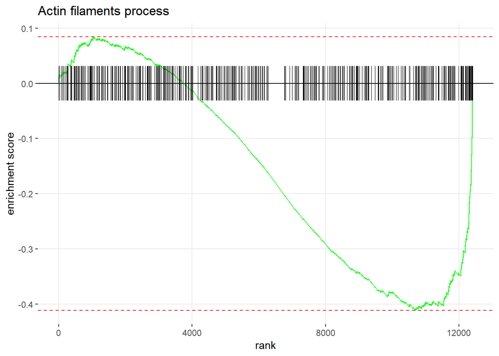

```r
plotEnrichment(pathways[["GO_ACTIN_FILAMENT_BASED_PROCESS"]],
               gene_list_de) +
  labs(title="Actin filaments process")
```

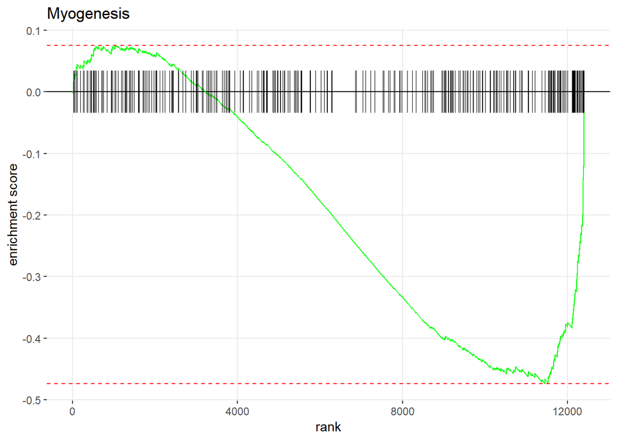

```r
plotEnrichment(pathways[["GO_MUSCLE_TISSUE_DEVELOPMENT"]], gene_list_de) +
  ggtitle("Myogenesis")
```

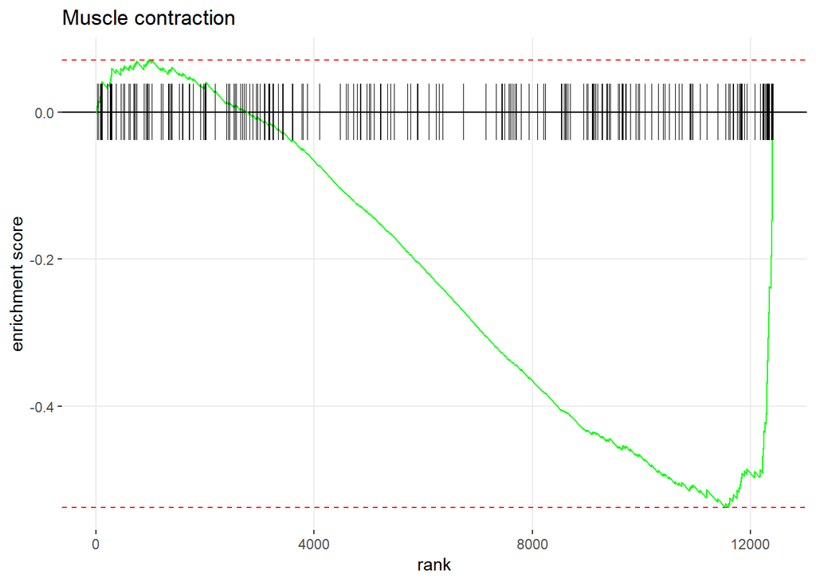

```r
plotEnrichment(pathways[["GO_MUSCLE_CONTRACTION"]], gene_list_de) +
  ggtitle("Muscle contraction")
```

```r
topPathwaysUp <- fr_de[ES > 0][head(order(pval), n=5), pathway]
topPathwaysDown <- fr_de[ES < 0][head(order(pval), n=5), pathway]
topPathways <- c(topPathwaysUp, rev(topPathwaysDown))
```

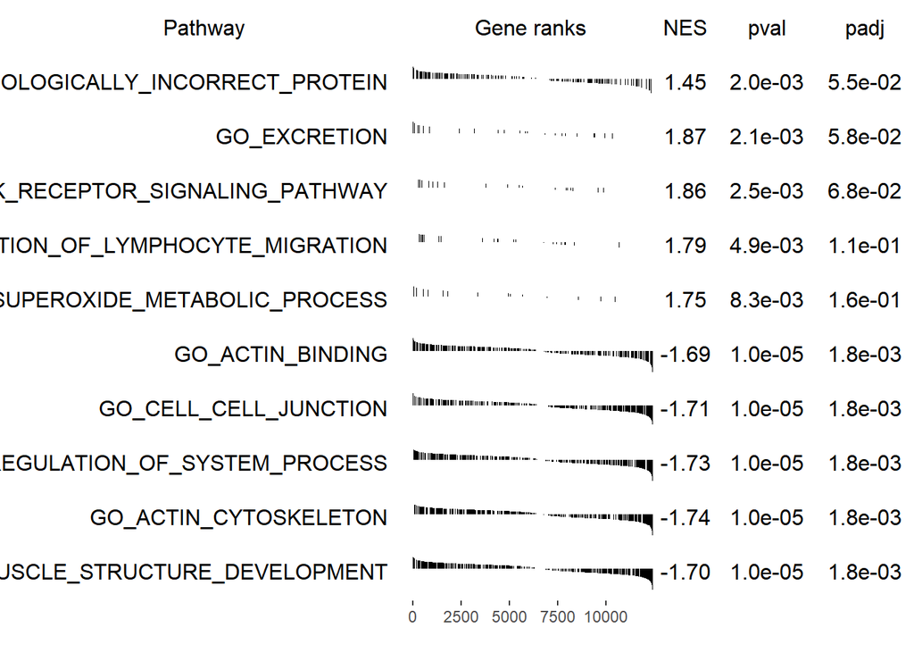

```r
plotGseaTable(pathways[topPathways], gene_list_de, fr_de,
              gseaParam=0.5)
```

### Compare wt_4d_HS vs 232_4d_HS

```r
#Сравнение wt_4d_HS vs 232_4d_HS
de2 <- results(dds, contrast = c("Condition", "wt_HS", "232_HS"))
de2_Genes <- row.names(de2)
de2$row_Genes <- de2_Genes
de2 <- as.data.table(de2)
#de <- de %>% filter(padj<0.01 & abs(log2FoldChange)>1)
de2 <- na.omit(de2)
de2$row_Genes <- as.character(de2$row_Genes)
de2 <- de2[!is.na(de2$row_Genes)]
de2[, row_Genes2 := mapIds(org.Mm.eg.db, keys=row_Genes,
                                        keytype="ENSEMBL", column="SYMBOL")]
de2 <- unique(de2, by = "row_Genes")
de2 <-de2[order(de2$padj),]
write.csv(de2, "table_de2.csv")
gene_list_de2 <- de2$log2FoldChange
genes2 <- bitr(de2$row_Genes,
              fromType = "ENSEMBL",
              toType = "ENTREZID",
              OrgDb = org.Mm.eg.db)
names(gene_list_de2) <- genes2$ENTREZID
#gene_list_de <- as.numeric(gene_list_de)
fr_de2 <- fgsea(pathways, gene_list_de2, nperm = 100000, nproc=4, minSize=15, maxSize=500)
head(fr_de2[order(pval), ])
```

```
##                                                 pathway     pval
## 1:       GO_NEGATIVE_REGULATION_OF_TRANSFERASE_ACTIVITY 0.000526
## 2:                  GO_MONOSACCHARIDE_METABOLIC_PROCESS 0.000727
## 3:                     GO_CHROMOSOME_CENTROMERIC_REGION 0.000741
## 4: GO_REGULATION_OF_CARDIAC_MUSCLE_CELL_DIFFERENTIATION 0.001219
## 5:            GO_NEGATIVE_REGULATION_OF_KINASE_ACTIVITY 0.001655
## 6:                                   GO_CELL_MATURATION 0.001793
##     padj     ES   NES nMoreExtreme size
## 1: 0.868 -0.332 -1.46           19  359
## 2: 0.868 -0.391 -1.59           30  172
## 3: 0.868 -0.379 -1.56           30  199
## 4: 0.868 -0.708 -1.87           60   18
## 5: 0.868 -0.342 -1.46           66  259
## 6: 0.868 -0.418 -1.61           79  118
##                                  leadingEdge
## 1: 56150,22628,12236,404634,228357,23797,...
## 2: 14719,16331,17279,228357,23797,110119,...
## 3:  56150,12236,404634,12615,68298,18817,...
## 4:  238161,13642,12391,23892,68278,21803,...
## 5: 22628,404634,228357,23797,13838,18817,...
## 6:  16874,15205,13838,268697,53321,54352,...
```

```r
fr_de2[order(padj)]
```

```
##                                                        pathway  pval
##    1: GO_DNA_DEPENDENT_DNA_REPLICATION_MAINTENANCE_OF_FIDELITY 0.334
##    2:                                      GO_CIRCADIAN_RHYTHM 0.141
##    3:                               GO_SPINAL_CORD_DEVELOPMENT 0.106
##    4:          GO_CEREBRAL_CORTEX_RADIAL_GLIA_GUIDED_MIGRATION 0.227
##    5:                GO_POSITIVE_REGULATION_OF_KINASE_ACTIVITY 0.194
##   ---
## 4579:   GO_NEGATIVE_REGULATION_OF_SMOOTHENED_SIGNALING_PATHWAY 0.998
## 4580:                                      GO_CHD_TYPE_COMPLEX 0.998
## 4581:                     GO_CARBOHYDRATE_DERIVATIVE_TRANSPORT 0.998
## 4582:                            GO_CYTOPLASMIC_STRESS_GRANULE 0.999
## 4583:                                   GO_NECROTIC_CELL_DEATH 0.999
##        padj     ES    NES nMoreExtreme size
##    1: 0.868 -0.378 -1.089        16463   26
##    2: 0.868  0.331  1.209         7880  133
```

[output cut: 21 more lines]

Graph for wt_4d_HS vs 232_4d_HS.

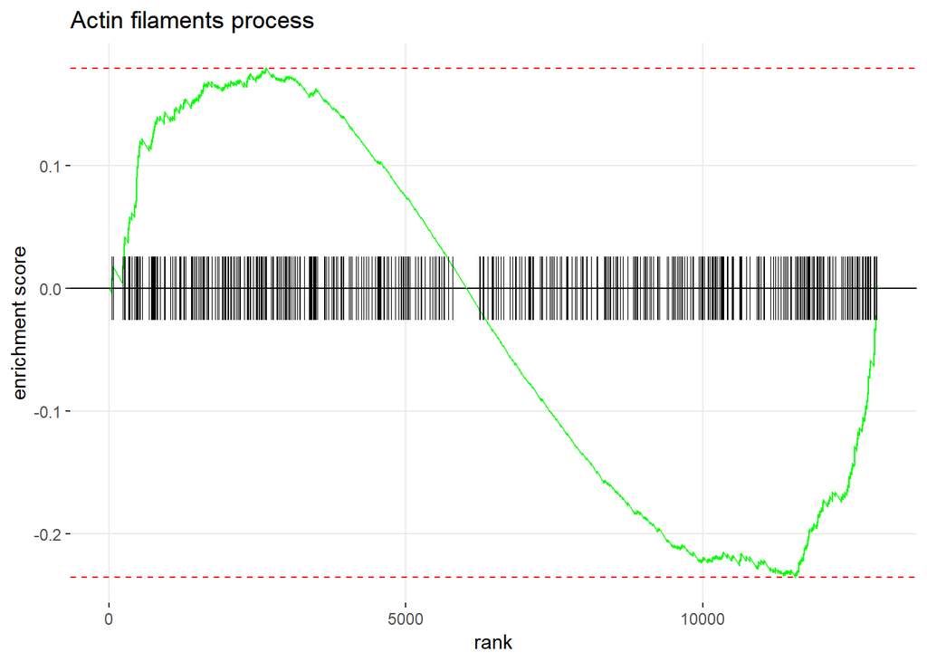

```r
plotEnrichment(pathways[["GO_ACTIN_FILAMENT_BASED_PROCESS"]],
               gene_list_de2) + labs(title="Actin filaments process")
```

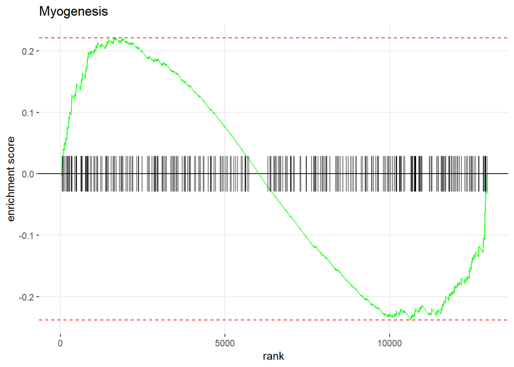

```r
plotEnrichment(pathways[["GO_MUSCLE_TISSUE_DEVELOPMENT"]], gene_list_de2) +
  ggtitle("Myogenesis")
```

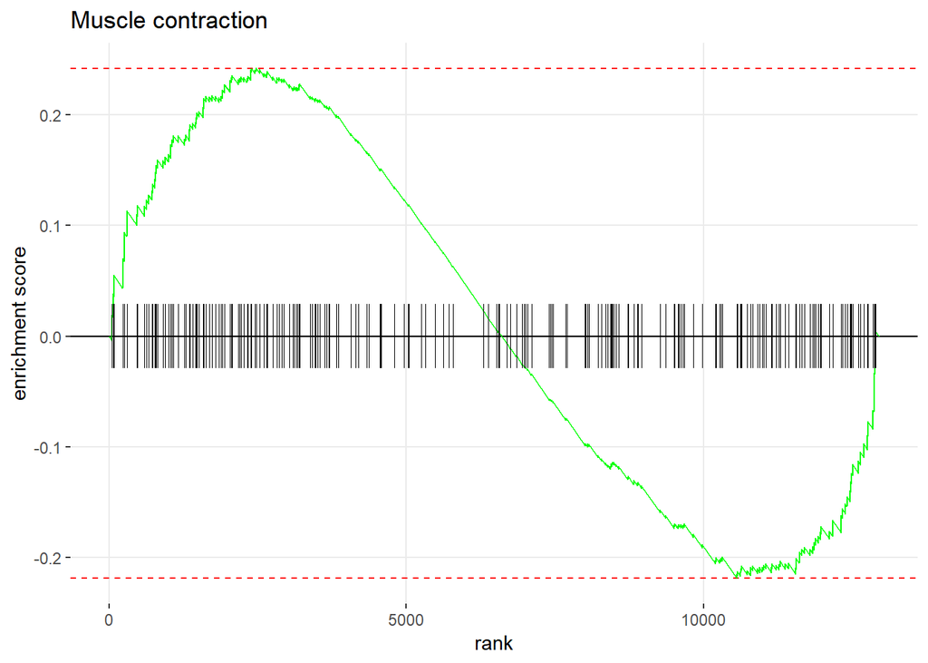

```r
plotEnrichment(pathways[["GO_MUSCLE_CONTRACTION"]], gene_list_de2) +
  ggtitle("Muscle contraction")
```

```r
topPathwaysUp2 <- fr_de2[ES > 0][head(order(pval), n=5), pathway]
topPathwaysDown2 <- fr_de2[ES < 0][head(order(pval), n=5), pathway]
topPathways2 <- c(topPathwaysUp2, rev(topPathwaysDown2))
```

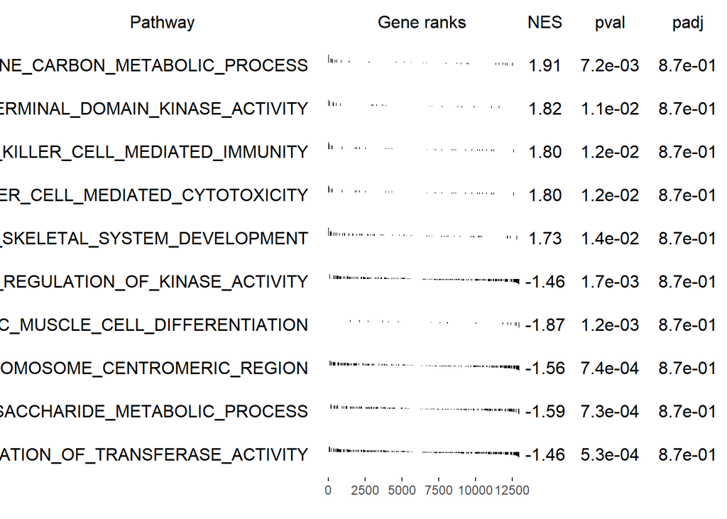

```r
plotGseaTable(pathways[topPathways2], gene_list_de2, fr_de2,
              gseaParam=0.5)
```

### GSEA analysis

```r
#Gene Set Enrichment Analysis with ClusterProfiler
#BiocManager::install("clusterProfiler")
require('clusterProfiler')
require(enrichplot)
require(DOSE)
require(ggplot2)
organism = "org.Mm.eg.db"
BiocManager::install(organism, character.only = TRUE)
require(organism, character.only = TRUE)
```

Add new columns with ENTREZID and SYMBOL of genes.

```r
p_adj_Genes <- row.names(p_adj_below_0.01)
p_adj_below_0.01$row_Genes <- p_adj_Genes
p_adj_below_0.01 <- as.data.table(p_adj_below_0.01)
p_adj_below_0.01 <- na.omit(p_adj_below_0.01)
p_adj_below_0.01$row_Genes <- as.character(p_adj_below_0.01$row_Genes)
p_adj_below_0.01[, row_Genes2 := mapIds(org.Mm.eg.db, keys=row_Genes,
                                        keytype="ENSEMBL", column="SYMBOL")]
p_adj_below_0.01[, row_Genes3 := mapIds(org.Mm.eg.db, keys=row_Genes,
                                        keytype="ENSEMBL", column="ENTREZID")]
p_adj_below_0.01 <-p_adj_below_0.01[order(p_adj_below_0.01$padj),]
p_adj_below_0.01$row_Genes3 <- as.character(p_adj_below_0.01$row_Genes3)
```

Drow some pictures. For wt_contr vs 232_contr:

[figure not shown]

```r
de[, row_Genes3 := mapIds(org.Mm.eg.db, keys=row_Genes,
                                        keytype="ENSEMBL", column="ENTREZID")]
ego_de <- enrichGO(gene          = de$row_Genes3,
                OrgDb         = org.Mm.eg.db,
                ont           = "BP",
                pAdjustMethod = "BH",
                pvalueCutoff  = 0.01,
                qvalueCutoff  = 0.05,
        readable      = TRUE)
dotplot(ego_de, showCategory=30)
```

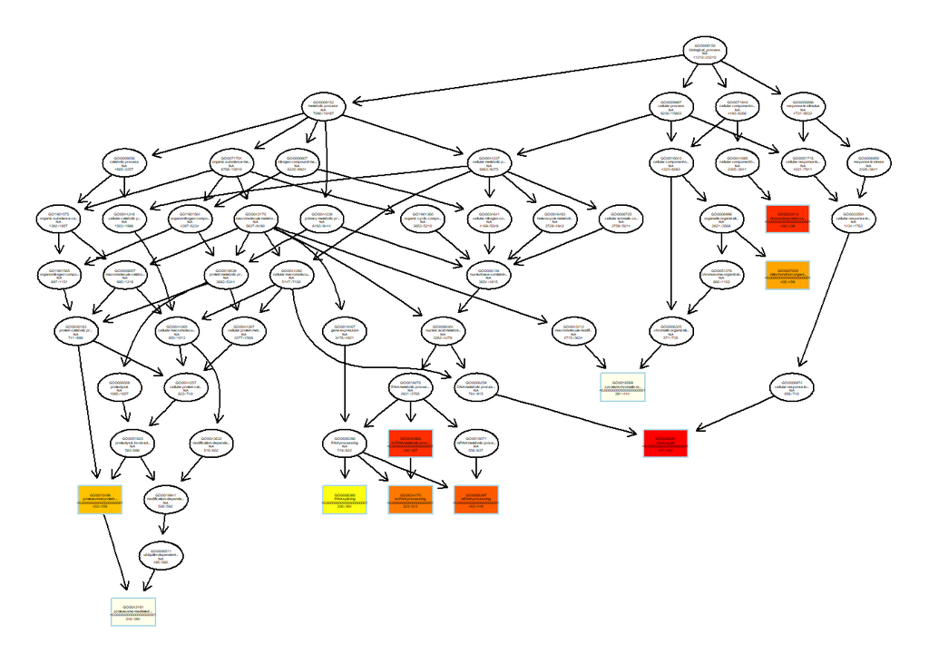

```r
#BiocManager::install("Rgraphviz")
#pdf("signal_pathways_large.pdf",width=1000,height=1000)
plot_GO <- plotGOgraph(ego_de)
```

```r
#dev.off()
```

For wt_HS vs 232_HS:

[figure not shown]

```r
de2[, row_Genes3 := mapIds(org.Mm.eg.db, keys=row_Genes,
                                        keytype="ENSEMBL", column="ENTREZID")]
ego_de2 <- enrichGO(gene          = de2$row_Genes3,
                OrgDb         = org.Mm.eg.db,
                ont           = "BP",
                pAdjustMethod = "BH",
                pvalueCutoff  = 0.01,
                qvalueCutoff  = 0.05,
        readable      = TRUE)
dotplot(ego_de2, showCategory=30)
```

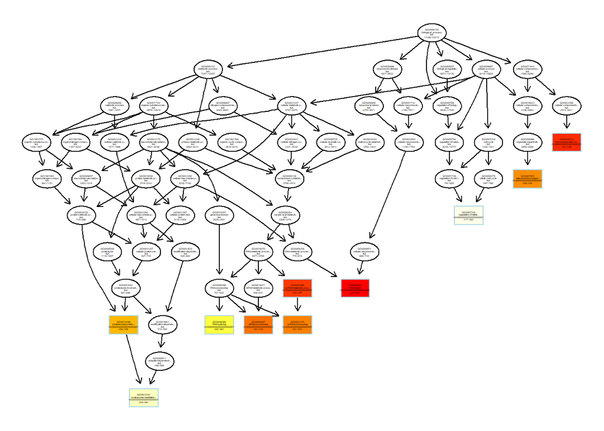

```r
#BiocManager::install("Rgraphviz")

#pdf("signal_pathways_large.pdf",width=1000,height=1000)
plot_GO <- plotGOgraph(ego_de2)
```

```r
#dev.off()
```